# Prosper loan data

## Preliminary Wrangling

This document explores dataset comprising of 113,937 loans with 81 variables on each loan, including loan amount, borrower rate (or interest rate), current loan status, borrower income etc.

```python
# import all packages and set plots to be embedded inline
import numpy as np
import pandas as pd
import matplotlib.pyplot as plt
import seaborn as sns

%matplotlib inline
```

```python
# Load in dataset in pandas dataframe, print statistics
df = pd.read_csv('prosperLoanData.csv')
```

```python
# high level of data shape, data types, and what data contains in each columns.
print(df.shape)
print(df.info())
print(df.head(10))
```

```
(113937, 81)
<class 'pandas.core.frame.DataFrame'>
RangeIndex: 113937 entries, 0 to 113936
Data columns (total 81 columns):
ListingKey                             113937 non-null object
ListingNumber                          113937 non-null int64
ListingCreationDate                    113937 non-null object
CreditGrade                            28953 non-null object
Term                                   113937 non-null int64
LoanStatus                             113937 non-null object
ClosedDate                             55089 non-null object
BorrowerAPR                            113912 non-null float64
BorrowerRate                           113937 non-null float64
LenderYield                            113937 non-null float64
EstimatedEffectiveYield                84853 non-null float64
EstimatedLoss                          84853 non-null float64
EstimatedReturn                        84853 non-null float64
ProsperRating (numeric)                84853 non-null float64
ProsperRating (Alpha)                  84853 non-null object
ProsperScore                           84853 non-null float64
ListingCategory (numeric)              113937 non-null int64
BorrowerState                          108422 non-null object
Occupation                             110349 non-null object
EmploymentStatus                       111682 non-null object
EmploymentStatusDuration               106312 non-null float64
IsBorrowerHomeowner                    113937 non-null bool
CurrentlyInGroup                       113937 non-null bool
GroupKey                               13341 non-null object
DateCreditPulled                       113937 non-null object
CreditScoreRangeLower                  113346 non-null float64
CreditScoreRangeUpper                  113346 non-null float64
FirstRecordedCreditLine                113240 non-null object
CurrentCreditLines                     106333 non-null float64
OpenCreditLines                        106333 non-null float64
TotalCreditLinespast7years             113240 non-null float64
OpenRevolvingAccounts                  113937 non-null int64
OpenRevolvingMonthlyPayment            113937 non-null int64
InquiriesLast6Months                   113240 non-null float64
TotalInquiries                         112778 non-null float64
CurrentDelinquencies                   113240 non-null float64
```

[output cut: 106 more lines]

```
9                0                          0                         0.0

  Investors
0       258
1         1
2        41
3       158
4        20
5         1
6         1
7         1
8         1
9         1

[10 rows x 81 columns]
```

### What is the structure of your dataset?

There are 113,937 loan data in dataset with 81 columns. Most variables are numeric. However few vaiables are categorical like

- Loan Status (Completed, Current, Past Due, Defaulted)
- Borrwer State
- Occupation
- Employmenet Status (self-employed, Employed)
- etc.

### What is/are the main feature(s) of interest in your dataset?

I am interested to figure out

- what features are best to predict whether the loan will be defaulted.
- what are factors contributed to low borrow rate i.e. high credit rate, high salary, etc?

### What features in the dataset do you think will help support your investigation into your feature(s) of interest?

I believed that loan defualted or not should be related to income level, debt to equity ratio (D/E), credit grade, occupation. While lower borrowing rate should come from something like higher income level.

## Univariate Exploration

I started by looking at Loan status. Then i created new column called LoanStatusReview which classified Lonstatus into defaulted and not defaulted. Not defaulted are all categories which have not been classified as defaulted.

```
Text(0.5,1,'Loan Status')
```

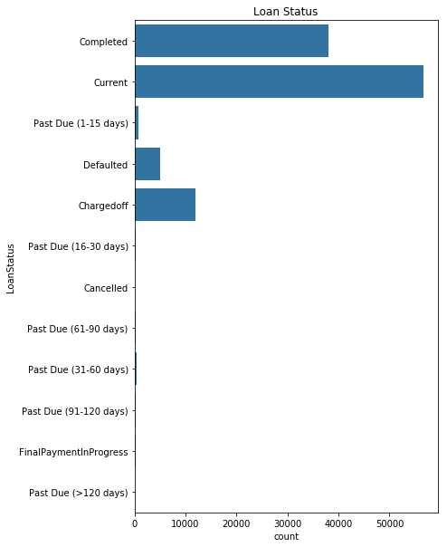

```python
# Look at loan status

plt.figure(figsize = (6,10))

default_color = sns.color_palette()[0]


sns.countplot(y = df.LoanStatus, color = default_color)
plt.title('Loan Status')
```

```python
# classified loan status as default and not default

df['LoanStatusReview'] = np.where(df.LoanStatus =='Defaulted','Defaulted','not Defaulted')
```

[output not shown]

[figure not shown]

```python
# plot loan term structure

fig, ax = plt.subplots(ncols = 2, figsize = (16,6))

default_color = sns.color_palette()[0]

sns.countplot(df[df['LoanStatusReview']=='not Defaulted'].Term, color = default_color, ax = ax[0])
ax[0].set_title('Lending term of loan not defaulted')
ax[0].set_ylim([0,90000])


sns.countplot(df[df['LoanStatusReview']=='Defaulted'].Term, color = default_color, ax = ax[1])
ax[1].set_title('Lending term of loan defaulted')
ax[1].set_ylim([0,10000])
```

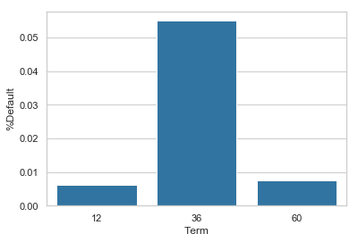

```python
# Percent Loan Defaul

df_Term = df.groupby(by =['Term','LoanStatusReview']).count()['ListingKey'].reset_index()

df_Term = df_Term.pivot(index ='Term',columns ='LoanStatusReview')['ListingKey'].reset_index()

df_Term['%Default'] = df_Term['Defaulted']/(df_Term['Defaulted']+df_Term['not Defaulted'])

sns.barplot(y ='%Default', x = 'Term', data = df_Term, color = default_color)
```

Look at the loan term structure. There are only 12 month, 36 month, and 60 months (1 year, 3 year, 5 year). Most of the loan is in 36 months term. 36 month loan term showed significantly higher percentage of loan default comparing to 12 month and 60 month.

Then I take a look at the relationship between credit grade vs default/ not default.

```
Text(0.5,1,'# of default by Credit Grade')
```

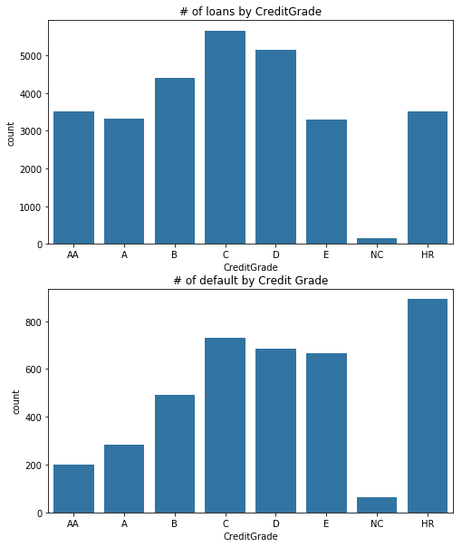

```python
# look at overall picture of credit grade

fig, ax = plt.subplots(nrows = 2, figsize = (8,10))

default_color = sns.color_palette()[0]

order_by = ['AA','A','B','C','D','E','NC','HR']

sns.countplot(data = df, x = 'CreditGrade', color = default_color, ax = ax[0], order = order_by)
ax[0].set_title('# of loans by CreditGrade')

sns.countplot(data = df[df.LoanStatusReview =='Defaulted'], x = 'CreditGrade', color = default_color, ax = ax[1], order = order_by)
ax[1].set_title('# of default by Credit Grade')
```

It seems like the higher the credit grade, the lower the defaul. Let check percentage by credit grade.

```
Text(0.5,1,'% Defaulted by Credit Grade')
```

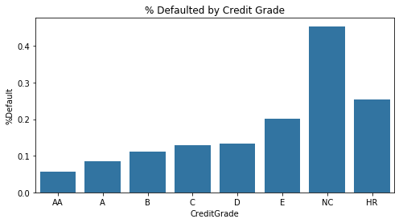

```python
# add one column to separate defaulted and not defaulted

df['LoanStatusReview'] = np.where(df.LoanStatus =='Defaulted','Defaulted','not Defaulted')

credit_group = df.groupby(by=['CreditGrade','LoanStatusReview']).count()['ListingKey'].reset_index()

credit_format = credit_group.pivot(index = 'CreditGrade', columns = 'LoanStatusReview')['ListingKey'].reset_index()

credit_format['%Default'] = credit_format['Defaulted']/ (credit_format['Defaulted'] + credit_format['not Defaulted'])

plt.figure(figsize = (8,4))

sns.barplot(x = 'CreditGrade', y= '%Default', data = credit_format, order = order_by, color = default_color)

plt.title('% Defaulted by Credit Grade')
```

It can confirm that the higher the credit grdate, the lower the percentage of default.

I take a look further at income range and occupation

```
Text(0.5,1,'Income range distribution of default borrower')
```

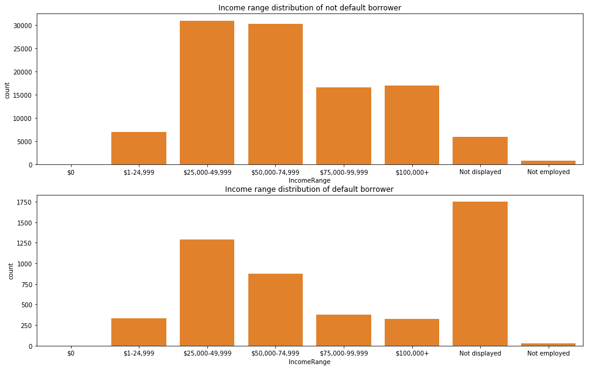

```python
# income range distribution

fig, ax = plt.subplots(nrows = 2, figsize = (16,10))

Order_income = ['$0','$1-24,999','$25,000-49,999','$50,000-74,999','$75,000-99,999','$100,000+','Not displayed','Not employed']

sns.countplot(data = df[df.LoanStatusReview =='not Defaulted'], x ='IncomeRange',order = Order_income, ax = ax[0],color =  sns.color_palette()[1])
ax[0].set_title('Income range distribution of not default borrower')

sns.countplot(data = df[df.LoanStatusReview=='Defaulted'], x= 'IncomeRange', order=Order_income, ax = ax[1], color =  sns.color_palette()[1])
ax[1].set_title ('Income range distribution of default borrower')
```

It seems like the default rate of not displayed income range is significantly higher than other income ranges.

### Of the features you investigated, were there any unusual distributions? Did you perform any operations on the data to tidy, adjust, or change the form of the data? If so, why did you do this?

I have done an adjustment of column loan status (separate data into defaulted and not defaulted). I did this in order to further analysis on what are the factors contributed to loan default.

## Bivariate Exploration

Start from look at pairwise correlations between few keys numeric feature

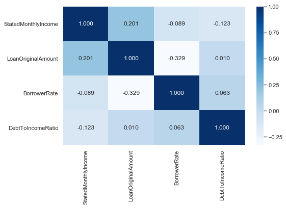

```python
num_var = ['StatedMonthlyIncome', 'LoanOriginalAmount', 'BorrowerRate', 'DebtToIncomeRatio']

plt.figure(figsize = (8,5))

sns.heatmap(df[num_var].corr(),annot = True, fmt ='.3f', cmap = "Blues")
```

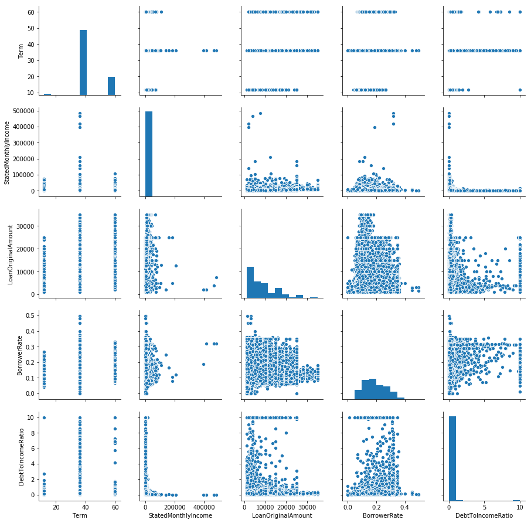

```python
# create pair plot

df_DI = df[df['DebtToIncomeRatio'].notnull()]

var = ['Term','StatedMonthlyIncome', 'LoanOriginalAmount','BorrowerRate','DebtToIncomeRatio']


sns.pairplot(df_DI[var],diag_kind="hist")
```

After that I take a look at reation ship between Credit grade and Borrow rate.

```
Text(0.5,1,'Creditgrade vs BorrowRate')
```

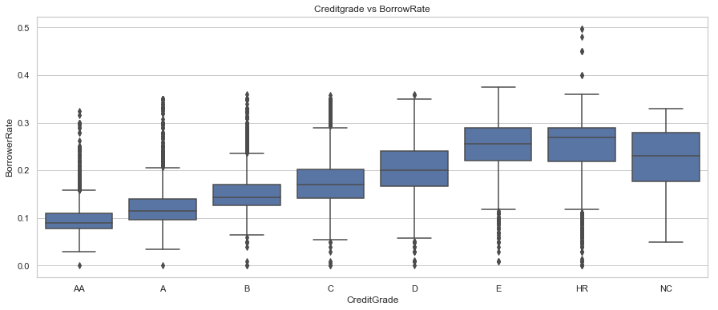

```python
# Boxplot of Credit grade vs Borrow rate

plt.figure(figsize=(15,6))

sns.boxplot(x ='CreditGrade', y ='BorrowerRate', data = df, order = ['AA','A','B','C','D','E','HR','NC'], color = default_color)

plt.title('Creditgrade vs BorrowRate')
```

It is clear relationship that the higher the credit grade, the lower the borrow rate.

Look at income range vs borrower rate and income range vs Loan Original amount.

[output not shown]

[figure not shown]

```python
# Income range vs Borrow rate

plt.figure(figsize=(15,6))

sns.boxplot(x ='IncomeRange', y ='BorrowerRate', data = df, order= Order_income, color = default_color)

plt.title('Income range vs Borrower rate')
```

The higher the income range, the lower the borrower rate.

Then checking income range vs loan original amount.

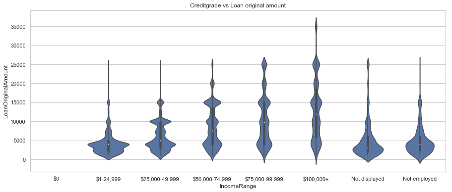

```python
# Income range vs Loan Original amount.

plt.figure(figsize=(15,6))

sns.violinplot(x ='IncomeRange', y ='LoanOriginalAmount', data = df, order = Order_income, color = default_color)

plt.title('Creditgrade vs Loan original amount')

plt.show()
```

With higher of the income, the loan original amount seems to be higher. And the distribution of borrower having salary bracket of 1-24999 has not much different from distribution of borrowers who has an income bracket of not displayed and not employed.

I am look at which states have highest borrowers vs default.

```
Text(0.5,1,'% Defaulted by state')
```

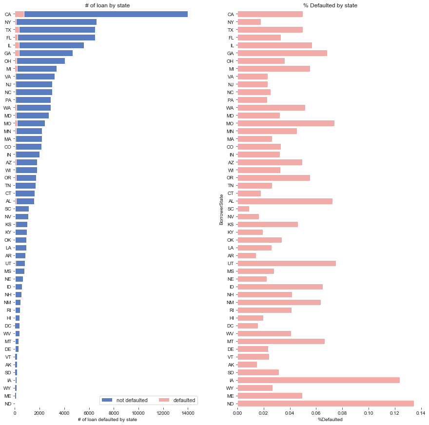

```python
borrow_state = df.groupby(by=['BorrowerState','LoanStatusReview']).count()['ListingKey'].reset_index()

z = borrow_state.pivot(index = 'BorrowerState',columns = 'LoanStatusReview')['ListingKey'].reset_index()

z['%Defaulted'] = z['Defaulted']/(z['Defaulted']+z['not Defaulted'])



f,ax = plt.subplots(ncols = 2, figsize = (15,15))

z = z.sort_values("not Defaulted",ascending = False)

sns.set(style = "whitegrid")

sns.set_color_codes("muted")
sns.barplot(x ="not Defaulted", y="BorrowerState", data = z, label = "not defaulted" ,color = "b", ax = ax[0])

sns.set_color_codes("pastel")
sns.barplot(x="Defaulted",  y="BorrowerState", data=z, label="defaulted", color="r", ax = ax[0])

ax[0].legend(ncol=2, loc="lower right", frameon=True)

ax[0].set(xlim=(0, 15000), ylabel="", xlabel="# of loan defaulted by state")

sns.despine(left=True, bottom=True)
ax[0].set_title("# of loan by state")

sns.set_color_codes("pastel")

sns.barplot(y = 'BorrowerState', x = '%Defaulted', data = z, color = 'r', label = 'Defaulted', ax = ax[1])
plt.title('% Defaulted by state')
```

### Talk about some of the relationships you observed in this part of the investigation. How did the feature(s) of interest vary with other features in the dataset?

It is clear that the higher the income bracket, the lower the borrower rate as well as the higher the credit rate, the lower the borrow rate.

## Multivariate Exploration

Coming back to the questions of what is the key factors to loan default look at both credit grade and debt to income ratio together.

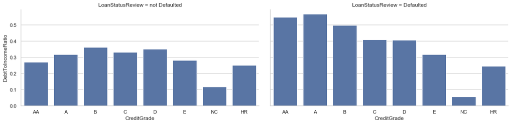

```python
# Look at default vs not default vs Credit Grade and debt to income ratio


g = sns.FacetGrid(data = df, col = 'LoanStatusReview',size = 4, aspect = 2, margin_titles = True)


g.map(sns.barplot, 'CreditGrade', 'DebtToIncomeRatio', ci = None,  data = df, order = order_by)
```

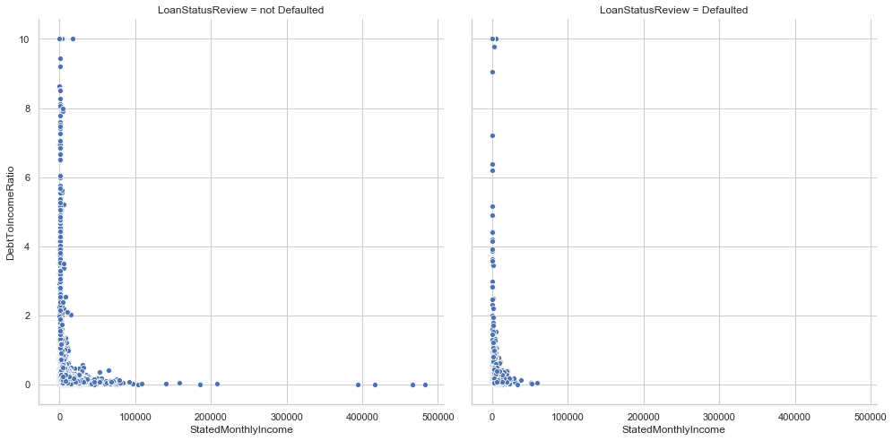

```python
# Compare DE Ratio with stated income compare default and not default

df_plot1 = df[['LoanStatusReview','StatedMonthlyIncome','DebtToIncomeRatio']]

g = sns.FacetGrid(data = df, col = 'LoanStatusReview', margin_titles = True,size = 7)

g.map(sns.scatterplot, 'StatedMonthlyIncome', 'DebtToIncomeRatio')
```

### Were there any interesting or surprising interactions between features?

Look at scatter plot of debt to income ratio vs stated monthly incomee separate by default/ not default. It seems like there was no different between stated income, debt to income ratio with whethe borrower will default or not. However,there was no default when borrower has high monthly income > 90K and low debt to income ratio.